# Fields – Basics

### The moving coil microphone

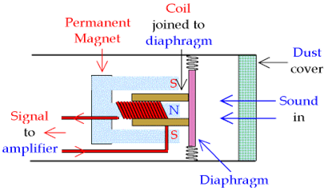

image

In a moving coil microphone, movement of the diaphragm by sound entering the device cause the coil to move in the field of the magnet generating a varying current that can be amplified.

### Eddy current heating

Have a look at the image below. Passing a current through the thick copper coil induces currents in the sample in the centre of the coil which can heat very rapidly to very high temperatures.

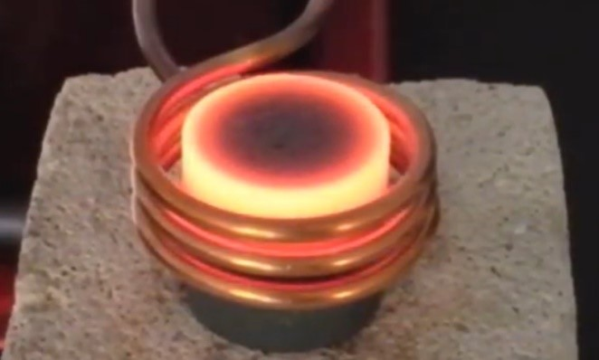

## Lenz’s Law

*Recommended reading:* Tipler & Mosca 28-3

Lenz’s Law states that the induced emf and induced current are in such a direction as to oppose the change that induces them.

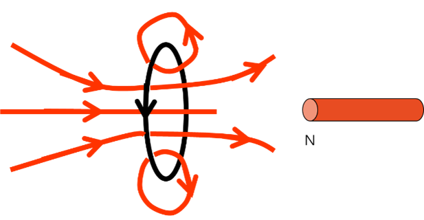

image

Consider the bar magnet and current loop in . The motion of the N pole towards the loop induces a current which flows so as to induce a N pole closest to the magnet’s N pole, and hence repel it.

Lenz’s Law can be used to work out the direction of the induced current (or the sign of the induced emf if the loop is not closed).

Note that the agent causing the motion, in this case the magnet, experiences a resisting force and so work is done. This work is equal to the internal energy produced in the coil by the current flow.

(It is interesting to consider what would happen if instead of opposing the motion, the resulting current actually assisted it. In that case the motion of a N pole towards a loop would induce a S pole in the loop. This S pole would attract the N pole producing an acceleration that would in turn produce a larger current and hence a larger attraction etc. etc. This would violate the Principle of Conservation of Energy.

In short, Lenz’s Law is associated with opposing **change**. Another way of interpreting it is to consider that the current will flow in such a way as to oppose the change in magnetic field through the loop. When the magnetic flux through a large conductor changes, eddy currents are induced. These currents produce the heating shown in the inductive heater at the end of .

## Inductance

*Recommended reading:* Tipler & Mosca 28-6

We have considered the case of an emf induced in a loop by a changing flux resulting from a changing current in another loop. However, such an emf can be induced by a changing flux through a coil brought about by a changing current in the **same** coil. This is known as the self-inductance, or more commonly just the **inductance** of the coil, and is usually represented by the symbol $L$. The SI unit of inductance is the Henry, equivalent to kg m$^2$ s$^{-2}$ A$^{-2}$.

The inductance relates the induced emf to the rate of change of current for a particular coil. So the voltage across an ideal inductor is given by $V = -L \frac{\d I}{\d t}$. An ideal inductor has zero resistance, and we would treat a real inductor as a combination of a resistor and inductor in series.

Note that this result depends only on the geometry of the coil and not on the voltage or the current. If the coil is filled with a magnetic material such as iron, the inductance, can be increased by a factor of $10^3$ – $10^4$.

In the next section of this course, we’ll look at electrical circuits that include resistance, capacitance and inductance and in particular at their response to alternating voltages.

# Circuits

## Aims of this section

At the end of this section you should be able to

- Analyse DC circuits containing resistance, capacitance and inductance and with more than one source of EMF to determine the current flowing at any point.
- Analyse AC circuits including the same types of components using complex notation for impedance to determine the current and its phase relation to the applied voltage.
- Determine the parameters associated with oscillations in LC and LCR circuits including the energy stored.

## Assumed knowledge

- Conventional current is the flow of positive changes from more positive potential to less positive potential. (Tipler & Mosca 25-1)
- Ohm’s Law – $V = IR$ (Tipler & Mosca 25-2)
- Expressions for combining resistors (and impedances in general) in series and parallel (Tipler & Mosca 25-4):
  - Series - $R = R_1 + R_2+ R_3 + ...$
  - Parallel – $\frac{1}{R} = \frac{1}{R_1} + \frac{1}{R_2} + \frac{1}{R_3} + ...$

## Components in circuits

We consider the following components;

- Sources of Electromotive force (EMF) that produce a potential difference between their terminals
  - Cells (batteries)
  - Generators
- Resistors
- Capacitors
- Inductors

These components present obstructions to current flow through circuits.

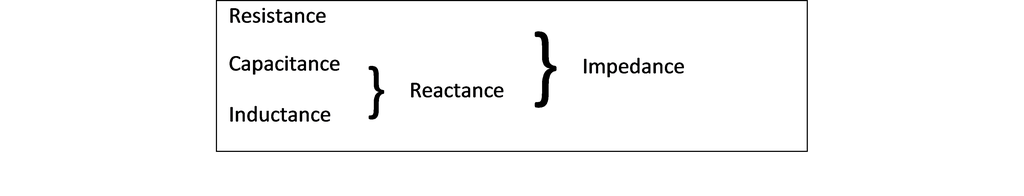

image

### Resistors

*Recommended reading:* Tipler & Mosca 25-2

Resistors are passive components that resist the flow of current within the circuit. Resistance is a type of impedance. Resistance is measured in Ohms ($\Omega$) where
$1 \; \Omega = \frac{1 \; \text{V}}{1 \; \text{A}} = 1 \; \text{kg} \; \text{m}^2 \; \text{A}^{-2} \; \text{s}^{-3}$
Ohmic resistors obey Ohm’s Law, which is
$$\begin{aligned}
V = IR
\end{aligned}$$

For an Ohmic resistor the resistance does not depend on current or potential drop. Real resistors will show some change in resistance with temperature.

### Capacitors

*Recommended reading:* Tipler & Mosca 24-3

Capacitor are reactive components. They have the intrinsic property of capacitance and because of this offer reactance to a change in voltage. Reactance is a type of **impedance** that depends on the applied voltage, in particular, the frequency of an alternating voltage.

Capacitance is measured in Farads (F) where  
$1 \; \text{F} = \frac{1 \; \text{C}}{1 \; \text{V}} = 1 \; \text{A}^2 \; \text{s}^4 \; \text{kg}^{-1} \; \text{m}^{-2}$

Capacitors are devices that store charge. The capacitance indicates how much charge can be stored at a given voltage. The relationship between voltage ($V$), charge ($Q$) and capacitance ($C$) in a capacitor is therefore

$$\begin{aligned}
V_C = \frac{Q}{C}
\end{aligned}$$

### Inductors

Inductors are reactive components. They have the intrinsic property of **inductance** and because of this offer reactance to a change in current.

Inductors are devices that resist a change in current because the changing magnetic field produced in the inductor by a changing current induces an EMF that opposes the change in current in the device itself:

$$\begin{aligned}
V_L = -L \frac{\d I}{\d t}
\end{aligned}$$

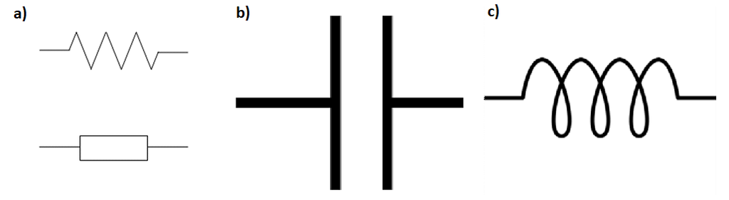

image

## Kirchhoff’s Rules

*Recommended reading:* Tipler & Mosca 25-5

Kirchoff’s Rules are simple rules which can be applied to any electrical circuit to compute voltages and currents.

### The loop rule

The loop rule expresses conservation of energy within the circuit. When current flows around any closed loop in the circuit the sum of all the potential changes must be zero otherwise energy would not be conserved. The rule states:  
“Around any closed loop the algebraic sum of the changes in potential must equal zero"

$$\begin{aligned}
\sum_i \epsilon_i =0
\end{aligned}$$

### The junction rule

The junction rule expresses conservation of charge within a circuit. Charge doesn’t collect at junctions so any flow of current in must be matched by current flow out of a junction. The rule states:

“The algebraic sum of currents into a junction must be equal to zero"

$$\begin{aligned}
I_1 = I_2 + I_3
\end{aligned}$$

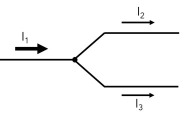

image

## Capacitors in DC circuits

*Recommended reading:* Tipler & Mosca 25-6

### Example: Series RC circuit

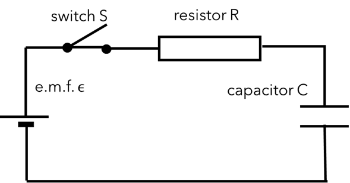

image

## Inductors in DC circuits

*Recommended reading:* Tipler & Mosca 28-6

The current through an inductor connected to a DC voltage will increase continuously. If there was no resistance this would continue for ever. But real circuits have resistance so there is some transient behaviour which is similar to the LC circuit capacitors but not quite the same. For the LR circuit shown below, the current and potential differences as a function of time are  
Current: $I = \frac{\epsilon}{R} \left( 1 - \exp \left( - \frac{Rt}{L} \right) \right)$.  
Potential difference across the inductor: $V_L = \epsilon \exp\left(- \frac{Rt}{L} \right)$.  
Potential difference across the resistor: $V_R = \epsilon \left (1 - \exp \left( - \frac{Rt}{L} \right) \right)$.

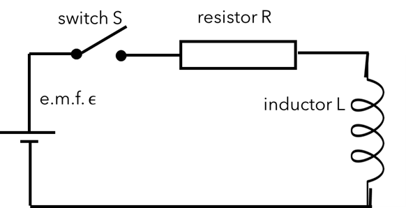

image

## Oscillations in LC and LCR circuits

*Recommended reading:* Tipler & Mosca 29-4, 29-6

Consider this circuit which includes a capacitor and inductor. Some charge is introduced, for example by connecting a battery across the capacitor. If the battery is then removed, we can calculate what happens next.

### Example: LC circuit

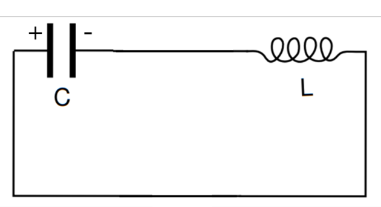

image

Using Kirchhoff’s **loop rule**, $\sum_i \epsilon_i = 0$.
The expressions for $V_C$ and $V_L$ are $V_C = \frac{Q}{C}$, $V_L = -L \frac{\d I}{\d t}$...
...and remembering that current is the rate of flow of charge. We can produce an equation for the charge on the capacitor and, from there, for the current:
$$\frac{\d^2 Q}{\d t^2} = -
\frac{1}{LC} Q
\label{eq:QtDiff}$$

This equation can be compared with the equation for undamped simple harmonic motion for a block on a spring (see Lecture 1 of Oscillations and Waves). By comparing with that equation, the solution to Equation
$$eq:QtDiff$$
is
$$Q = Q_0 \cos(\omega_0 t + \delta)$$

with the natural frequency given by $\omega_0 = \sqrt{ \frac{1}{LC} }$.  
Now add some resistance into the same circuit to create an LCR circuit. The resistance dissipates energy and so the energy in the circuit decreases with time i.e. the oscillations are damped.

The equation for the charge on the capacitor is:
$$L \frac{ \d^2 Q}{\d t^2} + R \frac{\d Q}{\d t} +
\frac{Q}{C} = 0$$

Applying an alternating voltage of frequency $\omega$ to an LCR circuit produces forced oscillations. The steady state solution is oscillations with frequency $\omega$ and an amplitude that depends on the applied frequency.

$$\begin{aligned}
Q_0 = \frac{V_0}{\sqrt{ L^2 (\omega_0^2 - \omega^2)^2 + R^2 \omega^2 }}
\end{aligned}$$

The maximum $Q_0$ and therefore the maximum current occurs at resonance, when $\omega_0 = \frac{1}{\sqrt{LC}}$, so it is possible to adjust $C$ or $L$ to tune to different frequencies as in a radio tuner. Ideally the resonance of your tuner would be sharp to reduce interference between radio stations with similar frequencies.

The sharpness of the resonance depends on the $Q$-factor for mechanical resonance:
$$\begin{aligned}
Q = \frac{2\pi}{ \left( \frac{|\Delta E|}{E} \right)_{cycle} } =
\frac{\omega_0}{\Delta \omega} = \frac{\omega_0 m}{b}
\end{aligned}$$

Making the usual replacements $m \rightarrow L$, $b \rightarrow R$, for electrical circuits:
$$\begin{aligned}
Q = \frac{\omega_0 L}{R}
\end{aligned}$$

The resonance is when $Q$ is large, so for a sharp peak (to only pick up one radio station at a time) you require that the circuit has a small resistance and a large inductance.

## Complex electrical impedance

The equation for forced oscillations of an LCR circuit, where the applied voltage is represented by the real part of $V_0 \e^{i\omega t}$, is

$$L \frac{ \d^2 Q}{\d t^2} + R \frac{\d
Q}{\d t} + \frac{Q}{C} = V_0 \e^{i\omega t}$$

and the solution for the charge on the capacitor is $Q = Q_0 \e^{ i(\omega t + \delta)}$, with the phase $\delta$ in terms of $C$, $L$ and $R$ for the general solution of the equation given by $\tan \delta = \frac{R}{ \omega L - \frac{1}{\omega C} }$.

The equations produced so far have been using charge $Q$ as the variable, but it would be more usual to measure current, and what we are interested in is the phase of the current relative to the applied voltage. However it is easy to determine the current from the charge.
$$Q =
Q_0 \e^{i(\omega t + \delta)} \therefore I = -\frac{\d Q}{\d t} = -i
\omega Q_0 \e^{i(\omega t + \delta)}$$

where the minus sign is because we have defined the current to be discharging the capacitor.

The amplitude of the current oscillations is $I_0 = \omega Q_0$. Using the fact that $-i = \e^{ -\frac{i\pi}{2} }$ we can rewrite the expression for $I$ in terms of a product of $\e^{i\omega t}$ (which is in phase with the applied voltage) and $\e^{i\delta^{'}}$ (where $\delta^{'}$ is the phase difference between the voltage and the current).

$$\begin{aligned}
I = I_0 \e^{- \frac{i\pi}{2} } \e^{i\omega t} \e^{i\delta} = I_0
\e^{i\omega t} \e^{i \left( \delta - \frac{\pi}{2} \right) } = I_0
\e^{i\omega t} \e^{i \delta^{'}} \\
\delta^{'} = \delta - \frac{\pi}{2} \therefore \tan\delta^{'} =
-\frac{1}{\tan\delta} = \frac{ \frac{1}{\omega C} - \omega L }{R}
\end{aligned}$$

If we represent the voltage by the real part of $V = V_0 \e^{i\omega t}$ using Ohm’s Law $V = IR$ gives
$$I = \frac{V}{R} = \frac{ V_0 \e^{i\omega t} }{R}
= I_0 \e^{i\omega t}$$

As the current is in phase with $V$,
$$Z_R =
\frac{V_0 \e^{i\omega t} }{ I_0 \e^{i\omega t}} = R$$

For a capacitor
$$V = \frac{Q}{C}
\therefore I = \frac{\d Q}{\d t} = C \frac{\d V}{\d t} = C V_0 i \omega
\e^{i\omega t}$$

Defining impedance as voltage divided by current:
$$Z_C = \frac{V}{I} = \frac{V_0 \e^{i\omega t} }{C
V_0 \e^{i\omega t}} = \frac{1}{i\omega C}$$

A similar argument leads to $Z_L = i\omega L$.

## Combining complex impedances

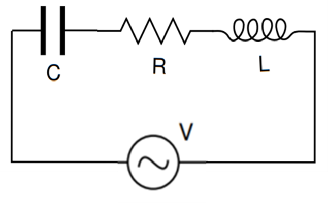

image

Impedances can be combined using the addition rules for resistors.
Series:
$$\begin{aligned}
Z = Z_1 + Z_2 + Z_3 + ...
\end{aligned}$$

Parallel:
$$\begin{aligned}
\frac{1}{Z} = \frac{1}{Z_1} + \frac{1}{Z_2} + \frac{1}{Z_3} + ...
\end{aligned}$$

For example, for the series circuit shown in , since all the impedances are in series we just sum them to get the overall impedance:
$$\begin{aligned}
Z_{tot} = R + Z_C + Z_L = R + \frac{1}{i\omega C} + i\omega L
\end{aligned}$$

To get the phase of the current with respect to the voltage, we write the impedance for the circuit in in the form $|Z| \e^{i\phi}$.

We can rewrite $Z_{tot}$ as a real and imaginary term:
$$\begin{aligned}
Z_{tot} = R + i\left( - \frac{1}{\omega C} + \omega L \right)
\end{aligned}$$

The magnitude of the impedance is therefore
$$\sqrt{ \Re(Z)^2 + \Im(Z)^2 } = \sqrt{ R^2 +
\left( \omega L - \frac{1}{\omega C} \right)^2 }$$

and the phase is $\phi = \tan^{-1} \frac{\Im(Z)}{ \Re(Z)}= tan^{-1}\left( \frac{ \omega L - \frac{1}{\omega C} }{R} \right)$

So the complex expression for the impedance is
$$Z = \sqrt{ R^2 + \left(\omega L - \frac{1}{\omega
C} \right)^2 } \exp \left( i tan^{-1} \left( \frac{\omega L -
\frac{1}{\omega C} }{R} \right)\right)$$

We can represent the impedance on an Argand diagram as shown below.

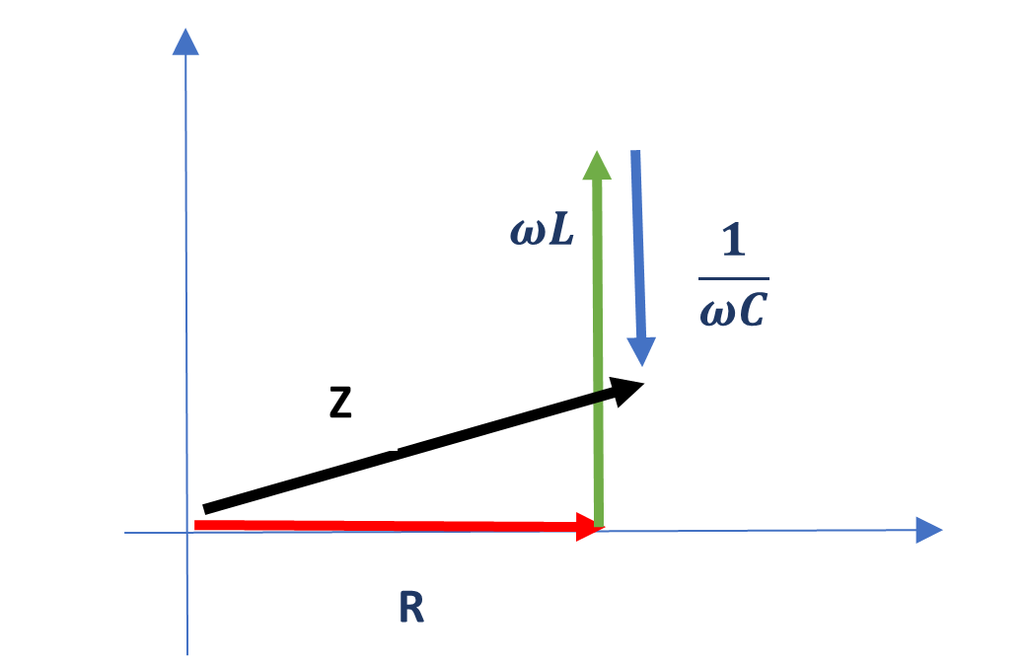

image

### Phase of current at resonance

The LC circuit has a natural frequency of $\omega_0 = \frac{1}{\sqrt{LC}}$. If a driving voltage is applied at this frequency then there is electrical resonance and at this frequency the maximum power is transferred into the circuit.

## Energy in LCR circuits

Rewriting the equation for the LCR circuit gives
$$V_0 \e^{i\omega t} = L \frac{\d I}{\d t} + RI +
\frac{Q}{C}$$

The power supplied to the circuit is $IV$. If the whole equation is multiplied by $I$,
$$I V_0 \e^{i\omega t} = IL \frac{\d I}{\d t} +
RI^2 + \frac{IQ}{C}$$

The term on the left-hand side is the power supplied to the circuit. The other terms must also be an energy rate. The middle term on the right-hand side should be familiar and is the rate at which power is dissipated in the resistor. The other two terms describe the rate at which power is stored or released from the inductor and the capacitor.

### Energy stored in an inductor

$IL \frac{\d I}{\d t}$ is the rate at which energy is stored in the magnetic field. The energy stored in the field at any point, $U_B$, can be found by integrating.
$$\frac{\d U_B}{\d t} =
IL \frac{\d I}{\d t} \therefore U_B = \frac{I^2 L}{2}$$

### Energy stored in a capacitor

$\frac{IQ}{C}$ is the rate at which energy is stored in the electric field. The energy stored, $U_C$, can be found by integrating.
$$\begin{aligned}
\frac{\d U_C}{\d t} = \frac{\d Q}{\d t} \frac{Q}{C} \therefore U_C =
\frac{Q^2}{2C} = \frac{CV^2}{2}
\end{aligned}$$

## Summary

| Capacitors | $V_C = \frac{Q}{C}$ | Inductors | $V_L = -L \frac{\d I}{\d t}$ |
| --- | --- | --- | --- |
|  | $U_C = \frac{1}{2} \frac{Q^2}{C}$ |  | $U_L = \frac{1}{2} LI^2$ |
| Complex impedance | $Z_C = \frac{1}{i \omega C}$ | Kirchoff’s Laws | $\sum_i \epsilon_i = 0$ around a loop |
|  | $Z_L = i \omega L$ |  | $\sum_i I_i = 0$ at a junction |

At the end of this section you should be able to:

- Analyse DC circuits containing **resistance**, **capacitance** and **inductance** and with more than one source of EMF to determine the current flowing at any point.
- Analyse AC circuits including the same types of components using complex notation for impedance to determine the current and its phase relation to the applied voltage.
- Determine the parameters associated with oscillations in LC and LCR circuits, including the energy stored.

# Exercise solutions

## Exercise solution

(Click here to go back to the exercise.)

At large $y$ ($y \gg d$) the expression you should get simplifies to

$$\begin{aligned}
E = \frac{1}{2 \pi \epsilon_0} \frac{p}{y^3}
\end{aligned}$$

## Exercise solution

(Click here to go back to the exercise.)

The field on the $x$-axis is
$$\begin{aligned}
E_x = \frac{xq}{4 \pi\epsilon_0 (x^2 + R^2)^{\frac{3}{2}}}
\end{aligned}$$

## Exercise solution

(Click here to go back to the exercise.)

## Exercise solution

(Click here to go back to the exercise.)

$$\label{eq:GLSol}
E_r = \frac{\lambda}{2\pi\epsilon_0 r}$$

## Exercise solution

(Click here to go back to the exercise.)

$$\label{eq:cycloF}
f = \frac{|q|\B}{2\pi m}$$

## Exercise solution

(Click here to go back to the exercise.)

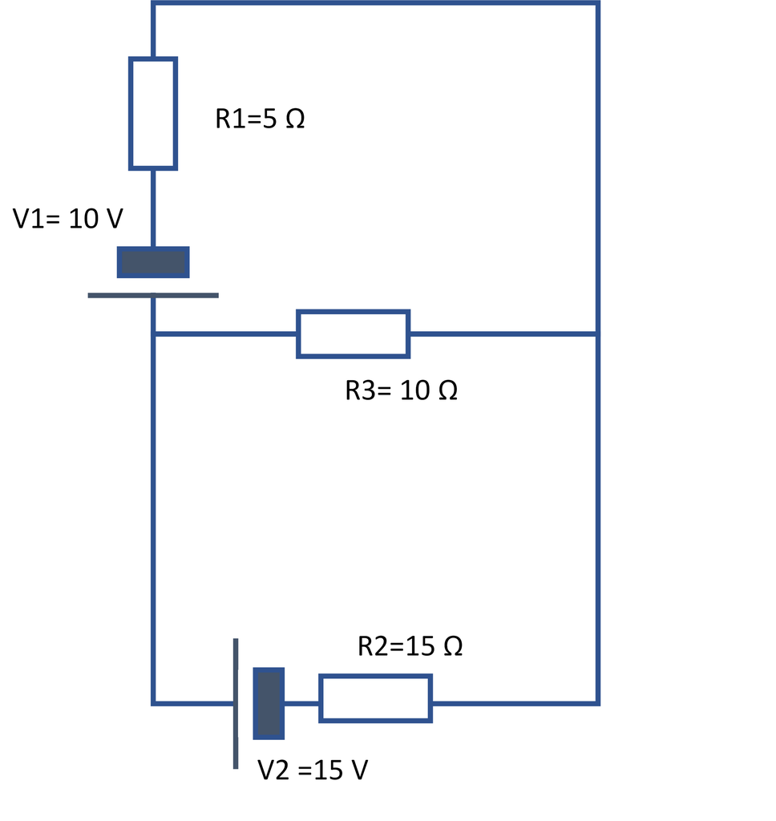

image

Consider $I_1$ to run clockwise around the top half of the loop and $I_2$ to run clockwise around the bottom half of the loop. $I_3$ is the current through the resistor $R_3$ from left to right. From the junction rule: $I_1 + I_3 = I_2$.  
From the loop rule going clockwise around the top loop: $-V_1 - (I_1 \times R_1 + (I_3 \times R_3) = 0$.  
From the loop rule going clockwise around the bottom loop: $V_2 - (I_3 \times R_3) - (I_2 \times R_2) = 0$.  
Since there are three equations and three unknowns (the three currents) the equations can be solved to give $I_1=-\frac{4}{11} A$, $I_2 = \frac{5}{11} A$, $I_3 = \frac{9}{11} A$. The negative sign on $I_1$ indicates that it is in the opposite direction to that chosen.